# 实验四 深度学习CNN

## 一、实验目的

1. 掌握简单的数据探索
2. 掌握CNN图像分类包括模型的定义、训练

## 二、实验环境

python 3.11.14 、jupyter notebook、tensorflow 2.20.0

## 三、实验内容

以道路上的交通拥堵为背景建模，在给定图像的基础上建立一个模型来预测车辆是否存在。实现一个CNN在cifar-10数据集上，看看它对车辆分类的效果如何。cifar-10数据集包含有各种各样的车辆(例如，汽车，卡车)和其他对象(例如，狗，猫)作为类。该数据集由50,000个训练实例和10,000个测试实例组成。每个实例都是一个32 × 32的RGB图像。这个数据集中有10种不同类型的对象。

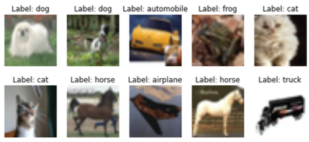

请大家设计CNN模型，并输出模型结构和预测精度，可参考代码示例。

### 导入必要库及显示中文设置

### 1.导入必要库

```python
# 导入依赖库
import tensorflow as tf
from tensorflow.keras import layers, models, optimizers
import numpy as np
import matplotlib.pyplot as plt

# 配置中文显示
plt.rcParams["font.family"] = ["SimHei"]
plt.rcParams["axes.unicode_minus"] = False
```

### 2. 加载并预处理 CIFAR-10 数据集

```python
# 加载CIFAR-10数据集（自动下载到本地）
(x_train, y_train), (x_test, y_test) = tf.keras.datasets.cifar10.load_data()

# CIFAR-10类别名称（索引对应标签）
class_names = ['飞机', '汽车', '鸟', '猫', '鹿',
               '狗', '青蛙', '马', '船', '卡车']

# 基本信息打印
print("数据集基本信息")
print(f"训练集形状：{x_train.shape} (样本数, 高度, 宽度, 通道数)")
print(f"测试集形状：{x_test.shape}")
print(f"训练集标签形状：{y_train.shape}")
print(f"测试集标签形状：{y_test.shape}")
```

```
数据集基本信息
训练集形状：(50000, 32, 32, 3) (样本数, 高度, 宽度, 通道数)
测试集形状：(10000, 32, 32, 3)
训练集标签形状：(50000, 1)
测试集标签形状：(10000, 1)
```

### 3.数据预处理

CIFAR-10 数据集像素值范围为0-255，需归一化到0-1区间（提升模型训练稳定性）；标签为整数格式，无需额外 one-hot 编码

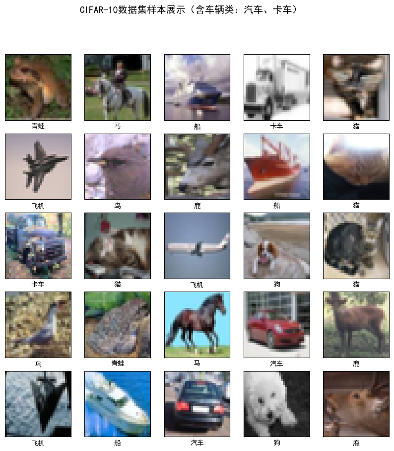

```python
# 1. 像素值归一化（从0-255缩放到0-1）
x_train_processed = x_train / 255.0  # 训练集归一化
x_test_processed = x_test / 255.0    # 测试集归一化

# 2. 标签格式确认（CIFAR-10标签为(样本数,1)的二维数组，展平为一维数组更简洁）
y_train_flat = y_train.flatten()  # 训练标签：(50000,1) → (50000,)
y_test_flat = y_test.flatten()    # 测试标签：(10000,1) → (10000,)

# 3. 数据探索：展示10类样本（含车辆类）
plt.figure(figsize=(10, 10))
for i in range(25):  # 展示25个样本
    plt.subplot(5, 5, i+1)
    plt.xticks([])
    plt.yticks([])
    plt.grid(False)
    # 随机选一个样本
    idx = np.random.randint(0, x_train.shape[0])
    plt.imshow(x_train[idx])
    # 显示类别名称（对应标签）
    plt.xlabel(class_names[y_train_flat[idx]])
plt.suptitle('CIFAR-10数据集样本展示（含车辆类：汽车、卡车）', fontsize=14)
plt.show()
```

### 4.定义 CNN 模型

参考 CNN 经典结构（卷积层提取特征→池化层降维→全连接层分类），适配 CIFAR-10 的32×32×3RGB 图像，避免过拟合并保证计算效率

```python
# 清除之前的模型残留
tf.keras.backend.clear_session()

# 定义CNN模型（Sequential顺序模型）
cnn_model = models.Sequential([
    layers.Input(shape=(32, 32, 3)), # 对应CIFAR-10的32×32×3 RGB图像

    # 第1卷积块：卷积层+池化层（提取低级特征：边缘、纹理）
    layers.Conv2D(
        filters=32,          # 卷积核数量（提取32种特征）
        kernel_size=(3, 3),  # 卷积核大小（3×3经典尺寸，兼顾感受野和参数）
        activation='relu',   # ReLU激活函数（引入非线性，增强表达能力）
        padding='same',      #  SAME填充（保持输入输出尺寸一致：32×32→32×32）
    ),
    layers.MaxPooling2D(
        pool_size=(2, 2),    # 2×2最大池化（降维：32×32→16×16，减少参数和过拟合）
        strides=(2, 2)       # 步长=2（无重叠，高效降维）
    ),

    # 第2卷积块：增加卷积核数量（提取更复杂的中层特征：形状、局部模式）
    layers.Conv2D(
        filters=64,          # 卷积核数量翻倍（特征更丰富）
        kernel_size=(3, 3),
        activation='relu',
        padding='same'
    ),
    layers.MaxPooling2D(pool_size=(2, 2), strides=(2, 2)),  # 降维：16×16→8×8

    # 第3卷积块（可选，进一步提升高级特征提取能力）
    layers.Conv2D(
        filters=128,         # 继续增加卷积核数量
        kernel_size=(3, 3),
        activation='relu',
        padding='same'
    ),
    layers.MaxPooling2D(pool_size=(2, 2), strides=(2, 2)),  # 降维：8×8→4×4

    # 展平层：将二维特征图（4×4×128）转为一维向量（用于全连接层）
    layers.Flatten(),  # 输出维度：4×4×128 = 2048

    # 全连接层1：综合所有特征（2048→256，减少维度）
    layers.Dense(256, activation='relu'),
    layers.Dropout(0.5),  # Dropout层（随机关闭50%神经元，防止过拟合）

    # 输出层：10类分类（对应CIFAR-10的10个类别）
    layers.Dense(10, activation='softmax')  # softmax激活：输出各类别概率（和为1）
])

# 输出模型结构
print("CNN模型结构详情：")
cnn_model.summary()  # 打印每层的输入输出形状、参数数量
```

```
CNN模型结构详情：
```

```
Model: "sequential"
```

```
┏━━━━━━━━━━━━━━━━━━━━━━━━━━━━━━━━━━━━━━┳━━━━━━━━━━━━━━━━━━━━━━━━━━━━━┳━━━━━━━━━━━━━━━━━┓
┃ Layer (type)                         ┃ Output Shape                ┃         Param # ┃
┡━━━━━━━━━━━━━━━━━━━━━━━━━━━━━━━━━━━━━━╇━━━━━━━━━━━━━━━━━━━━━━━━━━━━━╇━━━━━━━━━━━━━━━━━┩
│ conv2d (Conv2D)                      │ (None, 32, 32, 32)          │             896 │
├──────────────────────────────────────┼─────────────────────────────┼─────────────────┤
│ max_pooling2d (MaxPooling2D)         │ (None, 16, 16, 32)          │               0 │
├──────────────────────────────────────┼─────────────────────────────┼─────────────────┤
│ conv2d_1 (Conv2D)                    │ (None, 16, 16, 64)          │          18,496 │
├──────────────────────────────────────┼─────────────────────────────┼─────────────────┤
│ max_pooling2d_1 (MaxPooling2D)       │ (None, 8, 8, 64)            │               0 │
├──────────────────────────────────────┼─────────────────────────────┼─────────────────┤
│ conv2d_2 (Conv2D)                    │ (None, 8, 8, 128)           │          73,856 │
├──────────────────────────────────────┼─────────────────────────────┼─────────────────┤
│ max_pooling2d_2 (MaxPooling2D)       │ (None, 4, 4, 128)           │               0 │
├──────────────────────────────────────┼─────────────────────────────┼─────────────────┤
│ flatten (Flatten)                    │ (None, 2048)                │               0 │
├──────────────────────────────────────┼─────────────────────────────┼─────────────────┤
│ dense (Dense)                        │ (None, 256)                 │         524,544 │
├──────────────────────────────────────┼─────────────────────────────┼─────────────────┤
│ dropout (Dropout)                    │ (None, 256)                 │               0 │
├──────────────────────────────────────┼─────────────────────────────┼─────────────────┤
│ dense_1 (Dense)                      │ (None, 10)                  │           2,570 │
└──────────────────────────────────────┴─────────────────────────────┴─────────────────┘
```

```
 Total params: 620,362 (2.37 MB)
```

```
 Trainable params: 620,362 (2.37 MB)
```

```
 Non-trainable params: 0 (0.00 B)
```

### 5.模型训练

配置优化器、损失函数，用训练集训练模型并监控验证集精度（防止过拟合）

```python
# 1. 模型编译（配置训练参数）
cnn_model.compile(
    optimizer=optimizers.Adam(learning_rate=1e-4),  # Adam优化器（学习率1e-4，稳定收敛）
    # 损失函数：SparseCategoricalCrossentropy（适配整数标签，无需one-hot编码）
    loss=tf.keras.losses.SparseCategoricalCrossentropy(from_logits=False),
    metrics=['accuracy']  # 评估指标：准确率（整体分类精度）
)

# 2. 模型训练（用训练集训练，10%训练数据作为验证集）
print("\n")
print("开始训练模型（共10轮，每轮输出训练/验证精度）：")
train_history = cnn_model.fit(
    x=x_train_processed,        # 预处理后的训练图像
    y=y_train_flat,             # 展平后的训练标签（整数）
    batch_size=32,              # 批次大小（每批32个样本，平衡速度和稳定性）
    epochs=10,                  # 训练轮次
    validation_split=0.1,       # 从训练集拆分10%作为验证集（监控过拟合）
    shuffle=True                # 每轮训练前打乱样本顺序（提升泛化能力）
)
```

[output not shown]

### 6.评估模型

计算整体测试精度（所有 10 类的平均精度）；计算车辆类专项精度（汽车、卡车，对应class_names索引 1 和 9，实验背景关注的类别）

```python
# 1. 整体测试精度（评估模型在未见过的测试集上的泛化能力）
print("整体模型评估（测试集）：")
test_loss, test_acc = cnn_model.evaluate(
    x=x_test_processed,
    y=y_test_flat,
    verbose=1
)
print(f"测试集整体损失：{test_loss:.4f}")
print(f"测试集整体准确率：{test_acc:.4f}（即 {test_acc*100:.2f}%）")

# 2. 车辆类专项精度（汽车：索引1，卡车：索引9）
print("车辆类专项精度评估（汽车+卡车）：")
# 步骤1：预测测试集所有样本的类别（取概率最大的类别索引）
y_pred_probs = cnn_model.predict(x_test_processed, verbose=0)  # 输出10类概率
y_pred = np.argmax(y_pred_probs, axis=1)  # 转换为类别索引（概率最大的类别）

# 步骤2：筛选测试集中的车辆类样本（标签为1：汽车，9：卡车）
vehicle_test_mask = (y_test_flat == 1) | (y_test_flat == 9)  # 车辆类掩码
vehicle_x_test = x_test_processed[vehicle_test_mask]        # 车辆类图像
vehicle_y_true = y_test_flat[vehicle_test_mask]             # 车辆类真实标签
vehicle_y_pred = y_pred[vehicle_test_mask]                  # 车辆类预测标签

# 步骤3：计算车辆类准确率
vehicle_correct = np.sum(vehicle_y_true == vehicle_y_pred)  # 预测正确的车辆样本数
vehicle_total = len(vehicle_y_true)                         # 车辆类总样本数
vehicle_acc = vehicle_correct / vehicle_total

# 步骤4：分别计算汽车、卡车的精度
car_mask = (y_test_flat == 1)  # 汽车（索引1）掩码
truck_mask = (y_test_flat == 9)  # 卡车（索引9）掩码

car_correct = np.sum(y_test_flat[car_mask] == y_pred[car_mask])
car_total = len(y_test_flat[car_mask])
car_acc = car_correct / car_total

truck_correct = np.sum(y_test_flat[truck_mask] == y_pred[truck_mask])
truck_total = len(y_test_flat[truck_mask])
truck_acc = truck_correct / truck_total

# 输出车辆类精度结果
print(f"测试集中车辆类总样本数：{vehicle_total}（汽车{car_total}个 + 卡车{truck_total}个）")
print(f"车辆类整体准确率：{vehicle_acc:.4f}（即 {vehicle_acc*100:.2f}%）")
print(f"汽车类（索引1）准确率：{car_acc:.4f}（{car_correct}/{car_total}）")
print(f"卡车类（索引9）准确率：{truck_acc:.4f}（{truck_correct}/{truck_total}）")
```

```
整体模型评估（测试集）：
313/313 ━━━━━━━━━━━━━━━━━━━━ 5s 17ms/step - accuracy: 0.6738 - loss: 0.9290
测试集整体损失：0.9290
测试集整体准确率：0.6738（即 67.38%）
车辆类专项精度评估（汽车+卡车）：
测试集中车辆类总样本数：2000（汽车1000个 + 卡车1000个）
车辆类整体准确率：0.7420（即 74.20%）
汽车类（索引1）准确率：0.7590（759/1000）
卡车类（索引9）准确率：0.7250（725/1000）
```

### 训练过程可视化

#### 损失 + 精度曲线

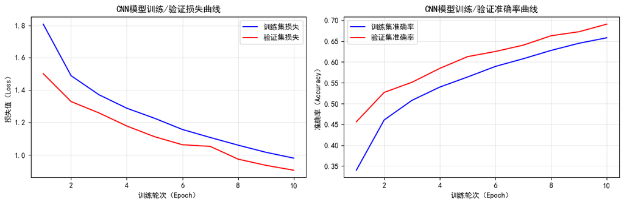

```python
# 提取训练历史数据
train_loss = train_history.history['loss']         # 训练集损失
val_loss = train_history.history['val_loss']       # 验证集损失
train_acc = train_history.history['accuracy']       # 训练集精度
val_acc = train_history.history['val_accuracy']     # 验证集精度

# 创建画布
plt.figure(figsize=(12, 4))

# 子图1：损失曲线（监控过拟合：若val_loss持续上升，说明过拟合）
plt.subplot(1, 2, 1)
plt.plot(range(1, len(train_loss)+1), train_loss, label='训练集损失', color='blue')
plt.plot(range(1, len(val_loss)+1), val_loss, label='验证集损失', color='red')
plt.xlabel('训练轮次（Epoch）')
plt.ylabel('损失值（Loss）')
plt.title('CNN模型训练/验证损失曲线')
plt.legend()
plt.grid(alpha=0.3)

# 子图2：精度曲线（监控模型收敛情况）
plt.subplot(1, 2, 2)
plt.plot(range(1, len(train_acc)+1), train_acc, label='训练集准确率', color='blue')
plt.plot(range(1, len(val_acc)+1), val_acc, label='验证集准确率', color='red')
plt.xlabel('训练轮次（Epoch）')
plt.ylabel('准确率（Accuracy）')
plt.title('CNN模型训练/验证准确率曲线')
plt.legend()
plt.grid(alpha=0.3)

# 保存或显示图像
plt.tight_layout()
plt.show()
```

#### 预测结果可视化

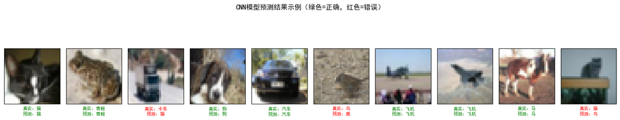

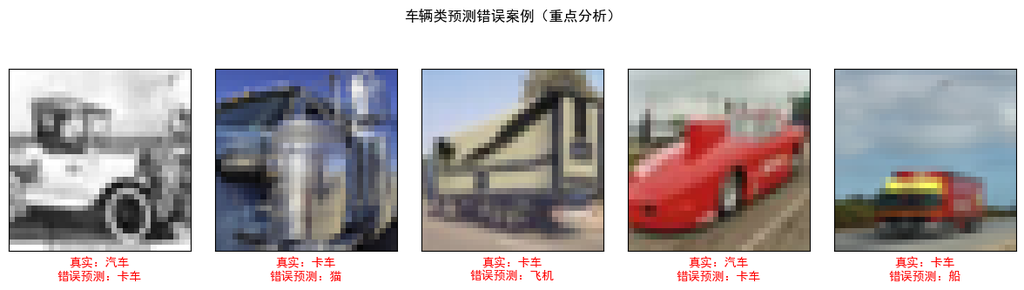

```python
# 筛选部分测试样本（正确+错误，含车辆类）
def show_predict_examples(num_examples=10):
    # 随机选num_examples个测试样本
    random_idx = np.random.choice(len(x_test_processed), num_examples, replace=False)
    sample_x = x_test_processed[random_idx]
    sample_y_true = y_test_flat[random_idx]
    sample_y_pred = y_pred[random_idx]

    # 创建画布
    plt.figure(figsize=(15, 3))
    for i in range(num_examples):
        plt.subplot(1, num_examples, i+1)
        plt.xticks([])
        plt.yticks([])
        plt.grid(False)

        # 显示图像
        plt.imshow(sample_x[i])

        # 判断预测是否正确，设置标签颜色（绿色：正确，红色：错误）
        if sample_y_true[i] == sample_y_pred[i]:
            color = 'green'
            status = '正确'
        else:
            color = 'red'
            status = '错误'

        # 标签内容（真实类别+预测类别）
        true_label = class_names[sample_y_true[i]]
        pred_label = class_names[sample_y_pred[i]]
        plt.xlabel(f"真实：{true_label}\n预测：{pred_label}", color=color, fontsize=8)

    plt.suptitle(f'CNN模型预测结果示例（绿色=正确，红色=错误）', fontsize=12)
    plt.tight_layout(rect=[0, 0, 1, 0.9])
    plt.show()

# 显示预测示例
show_predict_examples(num_examples=10)

# 单独显示车辆类的预测错误案例
def show_vehicle_error_examples(num_examples=5):
    # 筛选车辆类中预测错误的样本
    vehicle_error_mask = (vehicle_y_true != vehicle_y_pred)  # 仅对比车辆类的真实/预测标签
    error_count = np.sum(vehicle_error_mask)

    if np.sum(vehicle_error_mask) == 0:
        print("车辆类预测全部正确，无错误案例可展示。")
        return

    error_idx = np.where(vehicle_error_mask)[0][:num_examples]  # 取前num_examples个错误样本
    sample_x = vehicle_x_test[error_idx]
    sample_y_true = vehicle_y_true[error_idx]
    sample_y_pred = vehicle_y_pred[error_idx]

    # 创建画布
    plt.figure(figsize=(12, 3))
    for i in range(len(error_idx)):
        plt.subplot(1, len(error_idx), i+1)
        plt.xticks([])
        plt.yticks([])
        plt.grid(False)

        # 显示图像
        plt.imshow(sample_x[i])

        # 标签内容（真实车辆类+错误预测类）
        true_label = class_names[sample_y_true[i]]
        pred_label = class_names[sample_y_pred[i]]
        plt.xlabel(f"真实：{true_label}\n错误预测：{pred_label}", color='red', fontsize=10)

    plt.suptitle(f'车辆类预测错误案例（重点分析）', fontsize=12)
    plt.tight_layout(rect=[0, 0, 1, 0.9])
    plt.show()

# 显示车辆类错误案例
show_vehicle_error_examples(num_examples=5)
```

### 7.实验结果总结

```python
print("CIFAR-10车辆分类")
print(f"1. 模型结构：3个卷积块（Conv2D+MaxPool2D）+ 1个展平层 + 2个全连接层 + Dropout层")
print(f"2. 整体测试精度：{test_acc*100:.2f}%（10类平均）")
print(f"3. 车辆类专项精度：")
print(f"   - 汽车类（索引1）：{car_acc*100:.2f}%（{car_correct}/{car_total}）")
print(f"   - 卡车类（索引9）：{truck_acc*100:.2f}%（{truck_correct}/{truck_total}）")
print(f"   - 车辆类整体：{vehicle_acc*100:.2f}%（{vehicle_correct}/{vehicle_total}）")
```

```
CIFAR-10车辆分类
1. 模型结构：3个卷积块（Conv2D+MaxPool2D）+ 1个展平层 + 2个全连接层 + Dropout层
2. 整体测试精度：67.38%（10类平均）
3. 车辆类专项精度：
   - 汽车类（索引1）：75.90%（759/1000）
   - 卡车类（索引9）：72.50%（725/1000）
   - 车辆类整体：74.20%（1484/2000）
```